# Chapter 4 Exercises - Bayes Rules!

## ✏️ Exercise 4.1

Five different prior models for $\pi$ are listed below. Label each with one of these descriptors:  
- somewhat favoring $\pi < 0.5$  
- strongly favoring $\pi < 0.5$  
- centering $\pi$ on 0.5  
- somewhat favoring $\pi > 0.5$  
- strongly favoring $\pi > 0.5$

1. Beta(1.8,1.8)
2. Beta(3,2)
3. Beta(1,10)
4. Beta(1,3)
5. Beta(17,2)

**Solution:**

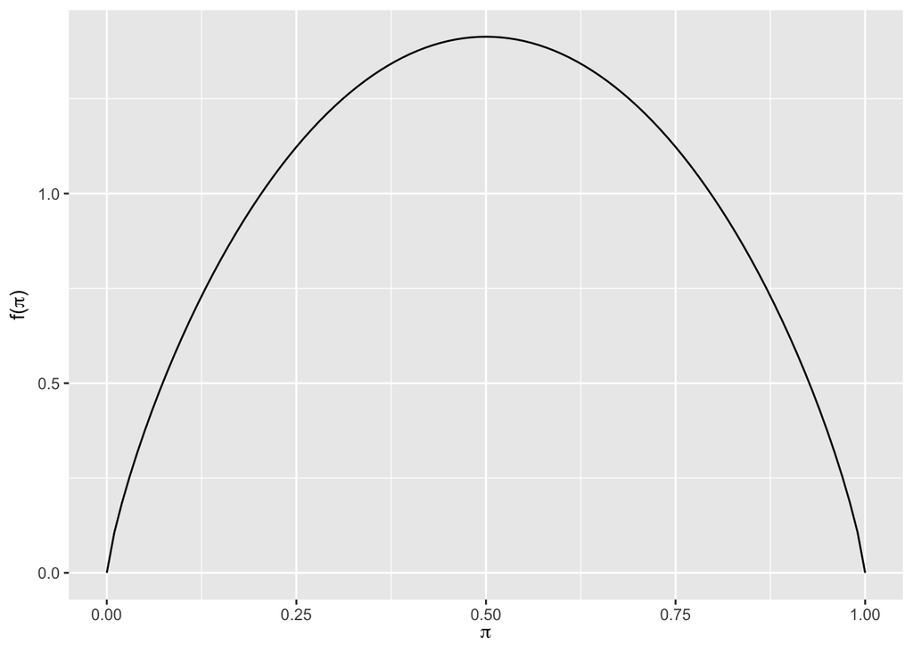

```r
plot_beta(alpha=1.8, beta=1.8)   # Centering on 0.5
```

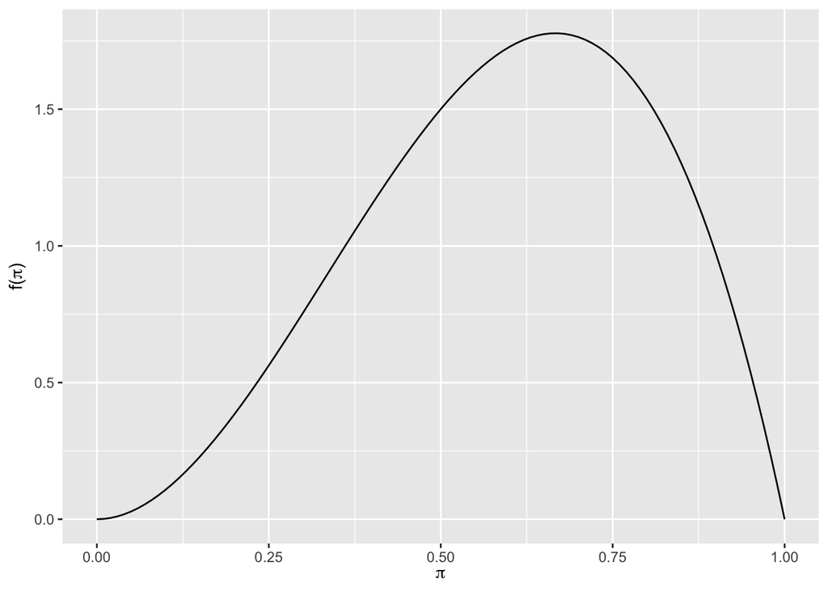

```r
plot_beta(alpha=3, beta=2)       # Somewhat favoring pi > 0.5
```

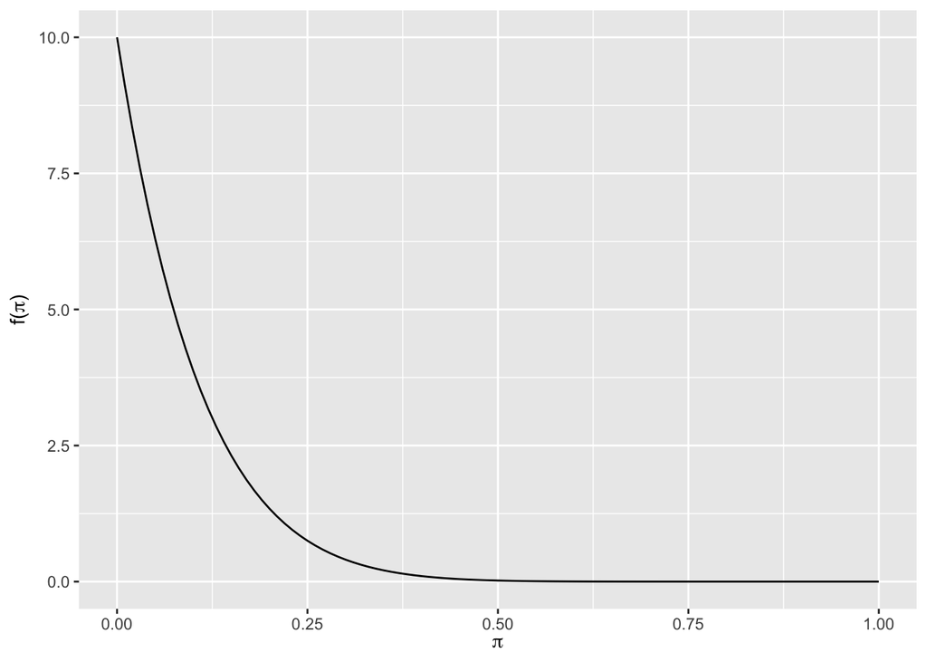

```r
plot_beta(alpha=1, beta=10)      # Strongly favoring pi < 0.5
```

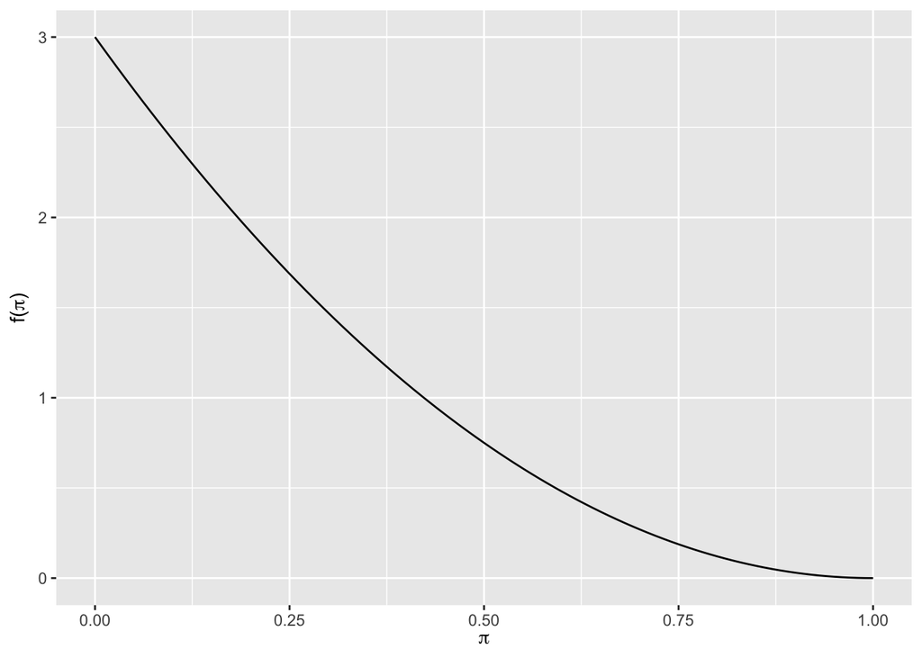

```r
plot_beta(alpha=1, beta=3)       # Somewhat favoring pi < 0.5
```

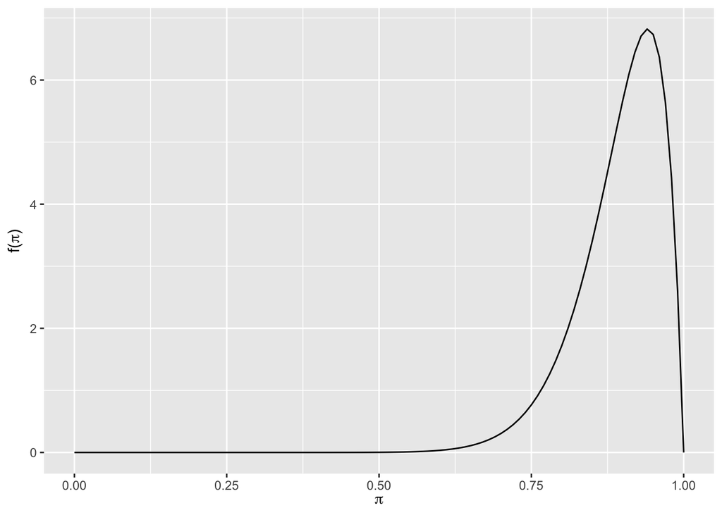

```r
plot_beta(alpha=17, beta=2)      # Strongly favoring pi > 0.5
```

## ✏️ Exercise 4.2

Which arguments to the `plot_beta_binomial()` function generated the plot below?

1. alpha = 2, beta = 2, y = 8, n = 11
2. alpha = 2, beta = 2, y = 3, n = 11
3. alpha = 3, beta = 8, y = 2, n = 6
4. alpha = 3, beta = 8, y = 4, n = 6
5. alpha = 3, beta = 8, y = 2, n = 4
6. alpha = 8, beta = 3, y = 2, n = 4

**Solution:**

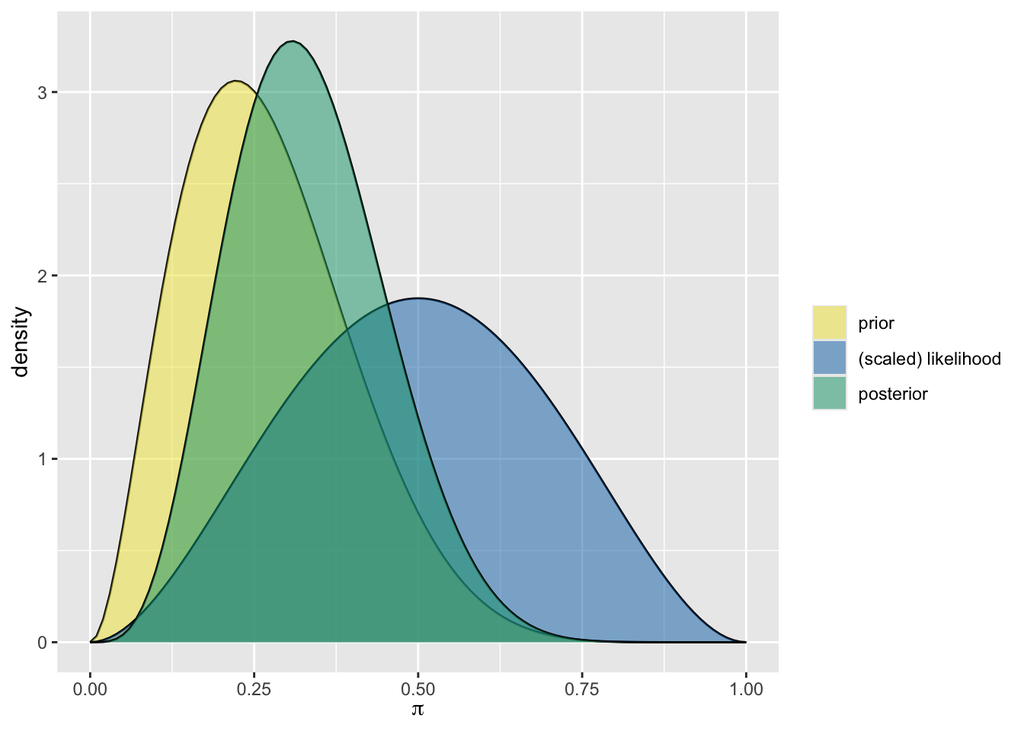

```r
plot_beta_binomial(alpha=3, beta=8, y=2, n=4)
```

## ✏️ Exercise 4.5

Chad peruses the shop’s website. On 3 of the past 7 days, they were still open at 2 p.m.. Complete the following for each of Chad’s coworkers: - simulate their posterior model; - create a histogram for the simulated posterior; and - use the simulation to approximate the posterior mean value of $\pi$.

**Solution:**

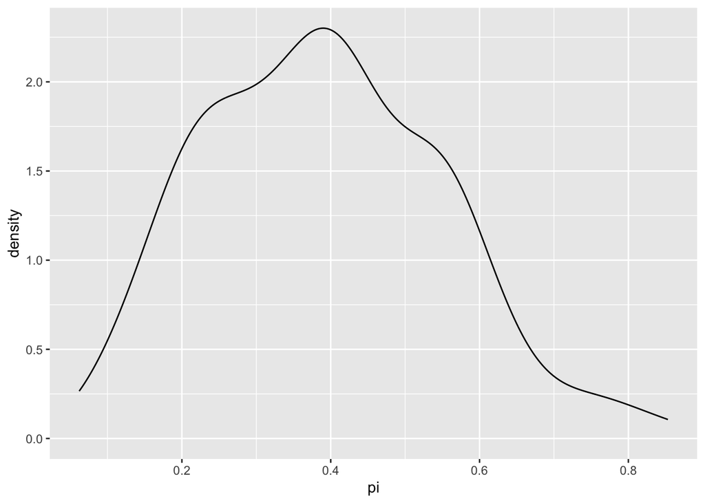

```r
set.seed(45872)
icecream_Kimya <- data.frame(pi=rbeta(1000,1,2)) %>%
  mutate(y=rbinom(1000, size=7, prob=pi))
icecream_Kimya_post <- icecream_Kimya %>%
  filter(y==3)

ggplot(icecream_Kimya_post, aes(x=pi)) +
  geom_density()
```

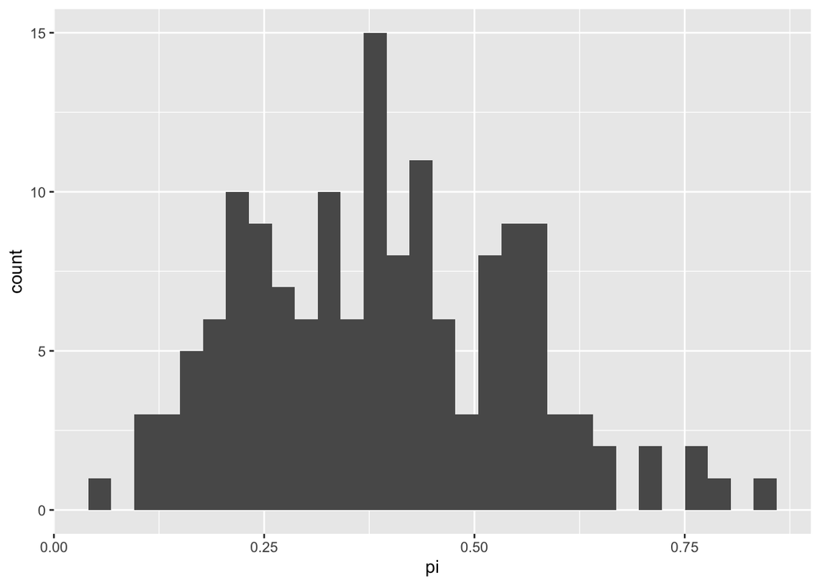

```r
ggplot(icecream_Kimya_post, aes(x=pi)) +
  geom_histogram()
```

```r
mean(icecream_Kimya_post$pi)
```

```
## [1] 0.3904016
```

## ✏️ Exercise 4.6

We compute the **posterior model** and **posterior mean** for each.

```r
# Kimya: Prior Beta(1, 2)
# Posterior: Beta(1 + 3, 2 + 4) = Beta(4, 6)
# Mean: 4 / (4 + 6) = 0.4

# Fernando: Prior Beta(0.5, 1)
# Posterior: Beta(0.5 + 3, 1 + 4) = Beta(3.5, 5)
# Mean: 3.5 / (3.5 + 5) ≈ 0.412

# Ciara: Prior Beta(3, 10)
# Posterior: Beta(3 + 3, 10 + 4) = Beta(6, 14)
# Mean: 6 / (6 + 14) = 0.3

# Taylor: Prior Beta(2, 0.1)
# Posterior: Beta(2 + 3, 0.1 + 4) = Beta(5, 4.1)
# Mean: 5 / (5 + 4.1) ≈ 0.549
```

## ✏️ Exercise 4.15

Let $\pi$ be the probability of success for some event of interest. You place a Beta(2, 3) prior on $\pi$, and are really impatient. Sequentially update your posterior for $\pi$ with each new observation below.

1. First observation: Success
2. Second observation: Success
3. Third observation: Failure
4. Fourth observation: Success

**Solution:**

```r
# Sequential updates:
# Beta(2, 3) → Beta(3, 3) → Beta(4, 3) → Beta(4, 4) → Beta(5, 4)
```

## ✏️ Exercise 4.19

In this exercise we’ll analyze $\pi$, the proportion of films that pass the Bechdel test, using the `bechdel` data. For each scenario below, specify the posterior model of $\pi$, and calculate the posterior mean and mode.

1. John has a flat Beta(1, 1) prior and analyzes movies from the year 1980.
2. The next day, John analyzes movies from the year 1990, while building off their analysis from the previous day.
3. The third day, John analyzes movies from the year 2000, while again building off of their analyses from the previous two days.
4. Jenna also starts her analysis with a Beta(1, 1) prior, but analyzes movies from 1980, 1990, 2000 all on day one.

**Solution:**

```r
data(bechdel, package = "bayesrules")

# John - 1980
John_1980 <- bechdel %>% filter(year == 1980)
summarize_beta_binomial(alpha=1, beta=1, y=4, n=14)
```

```
##       model alpha beta   mean      mode        var        sd
## 1     prior     1    1 0.5000       NaN 0.08333333 0.2886751
## 2 posterior     5   11 0.3125 0.2857143 0.01263787 0.1124183
```

```r
# John - 1990 (updated posterior)
John_1990 <- bechdel %>% filter(year == 1990)
summarize_beta_binomial(alpha=5, beta=11, y=6, n=15)
```

```
##       model alpha beta      mean      mode         var         sd
## 1     prior     5   11 0.3125000 0.2857143 0.012637868 0.11241827
## 2 posterior    11   20 0.3548387 0.3448276 0.007154006 0.08458136
```

```r
# John - 2000 (updated posterior again)
John_2000 <- bechdel %>% filter(year == 2000)
summarize_beta_binomial(alpha=11, beta=20, y=29, n=63)
```

```
##       model alpha beta      mean      mode         var         sd
## 1     prior    11   20 0.3548387 0.3448276 0.007154006 0.08458136
## 2 posterior    40   54 0.4255319 0.4239130 0.002573205 0.05072677
```

```r
# Jenna - all years at once
Jenna <- bechdel %>% filter(year %in% c(1980, 1990, 2000))
summarize_beta_binomial(alpha=1, beta=1, y=39, n=92)
```

```
##       model alpha beta      mean     mode         var         sd
## 1     prior     1    1 0.5000000      NaN 0.083333333 0.28867513
## 2 posterior    40   54 0.4255319 0.423913 0.002573205 0.05072677
```